# Ford Gobike

## Preliminary Wrangling

> In this project we'll be analyzing data associated with information about individual rides made in a bike-sharing system covering the greater San Francisco Bay area.

> **the dataset includes:**

> > **183412 rows** , and **16 variables**

> > **Variables meaning:**

> > **1 - Trip Duration (seconds)**

> > **2 - Start Time and Date** Identification of each appointment.

> > **15 - Member Gender** Female, Male, or Other.

> > **16 - Bike Sahre For all Trip** No or Yes.

```python
# import all packages and set plots to be embedded inline
import numpy as np
import pandas as pd
import matplotlib.pyplot as plt
import seaborn as sns # for data visualization
import calendar
from datetime import datetime
from datetime import date

%matplotlib inline
```

> Load in your dataset and describe its properties through the questions below. Try and motivate your exploration goals through this section.

```python
# load in the dataset into a pandas dataframe, print statistics
df = pd.read_csv("201902-fordgobike-tripdata.csv")
```

```python
# high-level overview of data shape and composition
df.shape
```

```
(183412, 16)
```

```python
df.dtypes
```

```
duration_sec                 int64
start_time                  object
end_time                    object
start_station_id           float64
start_station_name          object
start_station_latitude     float64
start_station_longitude    float64
end_station_id             float64
end_station_name            object
end_station_latitude       float64
end_station_longitude      float64
bike_id                      int64
user_type                   object
member_birth_year          float64
member_gender               object
bike_share_for_all_trip     object
dtype: object
```

```python
df.head(10)
```

|  | duration_sec | start_time | end_time | start_station_id | start_station_name | start_station_latitude | start_station_longitude | end_station_id | end_station_name | end_station_latitude | end_station_longitude | bike_id | user_type | member_birth_year | member_gender | bike_share_for_all_trip |
| --- | --- | --- | --- | --- | --- | --- | --- | --- | --- | --- | --- | --- | --- | --- | --- | --- |
| 0 | 52185 | 2019-02-28 17:32:10.1450 | 2019-03-01 08:01:55.9750 | 21.0 | Montgomery St BART Station (Market St at 2nd St) | 37.789625 | -122.400811 | 13.0 | Commercial St at Montgomery St | 37.794231 | -122.402923 | 4902 | Customer | 1984.0 | Male | No |
| 1 | 42521 | 2019-02-28 18:53:21.7890 | 2019-03-01 06:42:03.0560 | 23.0 | The Embarcadero at Steuart St | 37.791464 | -122.391034 | 81.0 | Berry St at 4th St | 37.775880 | -122.393170 | 2535 | Customer | NaN | NaN | No |
| 2 | 61854 | 2019-02-28 12:13:13.2180 | 2019-03-01 05:24:08.1460 | 86.0 | Market St at Dolores St | 37.769305 | -122.426826 | 3.0 | Powell St BART Station (Market St at 4th St) | 37.786375 | -122.404904 | 5905 | Customer | 1972.0 | Male | No |
| 3 | 36490 | 2019-02-28 17:54:26.0100 | 2019-03-01 04:02:36.8420 | 375.0 | Grove St at Masonic Ave | 37.774836 | -122.446546 | 70.0 | Central Ave at Fell St | 37.773311 | -122.444293 | 6638 | Subscriber | 1989.0 | Other | No |
| 4 | 1585 | 2019-02-28 23:54:18.5490 | 2019-03-01 00:20:44.0740 | 7.0 | Frank H Ogawa Plaza | 37.804562 | -122.271738 | 222.0 | 10th Ave at E 15th St | 37.792714 | -122.248780 | 4898 | Subscriber | 1974.0 | Male | Yes |
| 5 | 1793 | 2019-02-28 23:49:58.6320 | 2019-03-01 00:19:51.7600 | 93.0 | 4th St at Mission Bay Blvd S | 37.770407 | -122.391198 | 323.0 | Broadway at Kearny | 37.798014 | -122.405950 | 5200 | Subscriber | 1959.0 | Male | No |
| 6 | 1147 | 2019-02-28 23:55:35.1040 | 2019-03-01 00:14:42.5880 | 300.0 | Palm St at Willow St | 37.317298 | -121.884995 | 312.0 | San Jose Diridon Station | 37.329732 | -121.901782 | 3803 | Subscriber | 1983.0 | Female | No |
| 7 | 1615 | 2019-02-28 23:41:06.7660 | 2019-03-01 00:08:02.7560 | 10.0 | Washington St at Kearny St | 37.795393 | -122.404770 | 127.0 | Valencia St at 21st St | 37.756708 | -122.421025 | 6329 | Subscriber | 1989.0 | Male | No |
| 8 | 1570 | 2019-02-28 23:41:48.7900 | 2019-03-01 00:07:59.7150 | 10.0 | Washington St at Kearny St | 37.795393 | -122.404770 | 127.0 | Valencia St at 21st St | 37.756708 | -122.421025 | 6548 | Subscriber | 1988.0 | Other | No |
| 9 | 1049 | 2019-02-28 23:49:47.6990 | 2019-03-01 00:07:17.0250 | 19.0 | Post St at Kearny St | 37.788975 | -122.403452 | 121.0 | Mission Playground | 37.759210 | -122.421339 | 6488 | Subscriber | 1992.0 | Male | No |

```python
df.isnull().sum()
```

```
duration_sec                  0
start_time                    0
end_time                      0
start_station_id            197
start_station_name          197
start_station_latitude        0
start_station_longitude       0
end_station_id              197
end_station_name            197
end_station_latitude          0
end_station_longitude         0
bike_id                       0
user_type                     0
member_birth_year          8265
member_gender              8265
bike_share_for_all_trip       0
dtype: int64
```

> **Comment:**

```python
df.info()
```

```
<class 'pandas.core.frame.DataFrame'>
RangeIndex: 183412 entries, 0 to 183411
Data columns (total 16 columns):
duration_sec               183412 non-null int64
start_time                 183412 non-null object
end_time                   183412 non-null object
start_station_id           183215 non-null float64
start_station_name         183215 non-null object
start_station_latitude     183412 non-null float64
start_station_longitude    183412 non-null float64
end_station_id             183215 non-null float64
end_station_name           183215 non-null object
end_station_latitude       183412 non-null float64
end_station_longitude      183412 non-null float64
bike_id                    183412 non-null int64
user_type                  183412 non-null object
member_birth_year          175147 non-null float64
member_gender              175147 non-null object
bike_share_for_all_trip    183412 non-null object
dtypes: float64(7), int64(2), object(7)
memory usage: 22.4+ MB
```

> **Comment:**

> start_time and end_time there data types needs to change into date time,

> and member_birth_year needs to chnage to int64

```python
df.describe()
```

|  | duration_sec | start_station_id | start_station_latitude | start_station_longitude | end_station_id | end_station_latitude | end_station_longitude | bike_id | member_birth_year |
| --- | --- | --- | --- | --- | --- | --- | --- | --- | --- |
| count | 183412.000000 | 183215.000000 | 183412.000000 | 183412.000000 | 183215.000000 | 183412.000000 | 183412.000000 | 183412.000000 | 175147.000000 |
| mean | 726.078435 | 138.590427 | 37.771223 | -122.352664 | 136.249123 | 37.771427 | -122.352250 | 4472.906375 | 1984.806437 |
| std | 1794.389780 | 111.778864 | 0.099581 | 0.117097 | 111.515131 | 0.099490 | 0.116673 | 1664.383394 | 10.116689 |
| min | 61.000000 | 3.000000 | 37.317298 | -122.453704 | 3.000000 | 37.317298 | -122.453704 | 11.000000 | 1878.000000 |
| 25% | 325.000000 | 47.000000 | 37.770083 | -122.412408 | 44.000000 | 37.770407 | -122.411726 | 3777.000000 | 1980.000000 |
| 50% | 514.000000 | 104.000000 | 37.780760 | -122.398285 | 100.000000 | 37.781010 | -122.398279 | 4958.000000 | 1987.000000 |
| 75% | 796.000000 | 239.000000 | 37.797280 | -122.286533 | 235.000000 | 37.797320 | -122.288045 | 5502.000000 | 1992.000000 |
| max | 85444.000000 | 398.000000 | 37.880222 | -121.874119 | 398.000000 | 37.880222 | -121.874119 | 6645.000000 | 2001.000000 |

> **Comment:**

> it would be better to add age column calculated from the members birth year to the if there is out laiers in the age

```python
#check for duplicates
sum(df.duplicated())
```

```
0
```

> **Comment:**

> -**there is no duplicated rows till now , may be hen we dropped the unneeded columns a duplicated rows appears** in the dataset.

```python
#check for the number of unique values in each column
df.nunique()
```

```
duration_sec                 4752
start_time                 183401
end_time                   183397
start_station_id              329
start_station_name            329
start_station_latitude        334
start_station_longitude       335
end_station_id                329
end_station_name              329
end_station_latitude          335
end_station_longitude         335
bike_id                      4646
user_type                       2
member_birth_year              75
member_gender                   3
bike_share_for_all_trip         2
dtype: int64
```

### What is/are the main feature(s) of interest in your dataset?

> there are interesting features like the trip duration in seconds i think there would be useful insights came from it if we see the relation between it and other features.

### What features in the dataset do you think will help support your investigation into your feature(s) of interest?

> i think taht user type, age and gender are the most feature will support my investigation , in which user type do more rides than the other , and which of them spend more duration.

## Before we do Exploration we are going to make some cleansing in our data

> -Dropping the un needed columns

> -Dropping rows contains null values

> -Dropping the duplicated rows if found after dropping nulls

> -Adding a new column have the age of each user

> -Change start time and end time data types

> -Change member_birth_year data type to int64

```python
def calculate_age (born_year):
    today = date.today()
    return today.year - born_year
```

```python
#drop not important columns
df_unNeeded = ['start_station_id','start_station_name','start_station_latitude','start_station_longitude','end_station_id','end_station_name','end_station_latitude', 'end_station_longitude', 'bike_id', 'bike_share_for_all_trip']
df=df.drop(columns = df_unNeeded)
```

```python
print(df.isnull().sum())
print("")

df = df.dropna()

print(df.isnull().sum())
print("")
```

```
duration_sec            0
start_time              0
end_time                0
user_type               0
member_birth_year    8265
member_gender        8265
dtype: int64

duration_sec         0
start_time           0
end_time             0
user_type            0
member_birth_year    0
member_gender        0
dtype: int64
```

```python
#check for duplicates after dropping the un needed columns and the null values
sum(df.duplicated())
```

```
0
```

> **Comments**

> no duplications

```python
df["age"]=""
df['age'] = calculate_age(df['member_birth_year'])
#Parsing age datatype to int64 datatype.
df['age']= df['age'].astype(np.int64)
```

```python
#Parsing member_birth_year datatype to int64 datatype.
df['member_birth_year']= df['member_birth_year'].astype(np.int64)
```

```python
#Parsing start_time object datatype to DateTime datatype.
df['start_time']= pd.to_datetime(df['start_time'])

#Parsing end_time object datatype to DateTime datatype.
df['end_time']= pd.to_datetime(df['end_time'])
```

```python
df.describe()
```

|  | duration_sec | member_birth_year | age |
| --- | --- | --- | --- |
| count | 175147.000000 | 175147.000000 | 175147.000000 |
| mean | 704.211845 | 1984.806437 | 35.193563 |
| std | 1641.608363 | 10.116689 | 10.116689 |
| min | 61.000000 | 1878.000000 | 19.000000 |
| 25% | 323.000000 | 1980.000000 | 28.000000 |
| 50% | 510.000000 | 1987.000000 | 33.000000 |
| 75% | 789.000000 | 1992.000000 | 40.000000 |
| max | 84548.000000 | 2001.000000 | 142.000000 |

> **Comments:**

> it looks like that the age have out laiers we will discover that later</b>

```python
df['year_of_ride'] =""
df['year_of_ride'] = df['start_time'].apply(lambda x: x.year)
```

```python
df["year_of_ride"].unique()
```

```
array([2019], dtype=int64)
```

> **Comments:**

> all the rides done in the same year which is 2019

```python
df['month_of_ride'] =""
df['month_of_ride'] = df['start_time'].apply(lambda x: x.month)
```

```python
df["month_of_ride"].unique()
```

```
array([2], dtype=int64)
```

> **Comments:**

> all the rides done in the same month which is february

## Univariate Exploration

> In this section, we are going to look at the distribution of the main variables one by one then get relations between them.

#### 1- Duration Sec

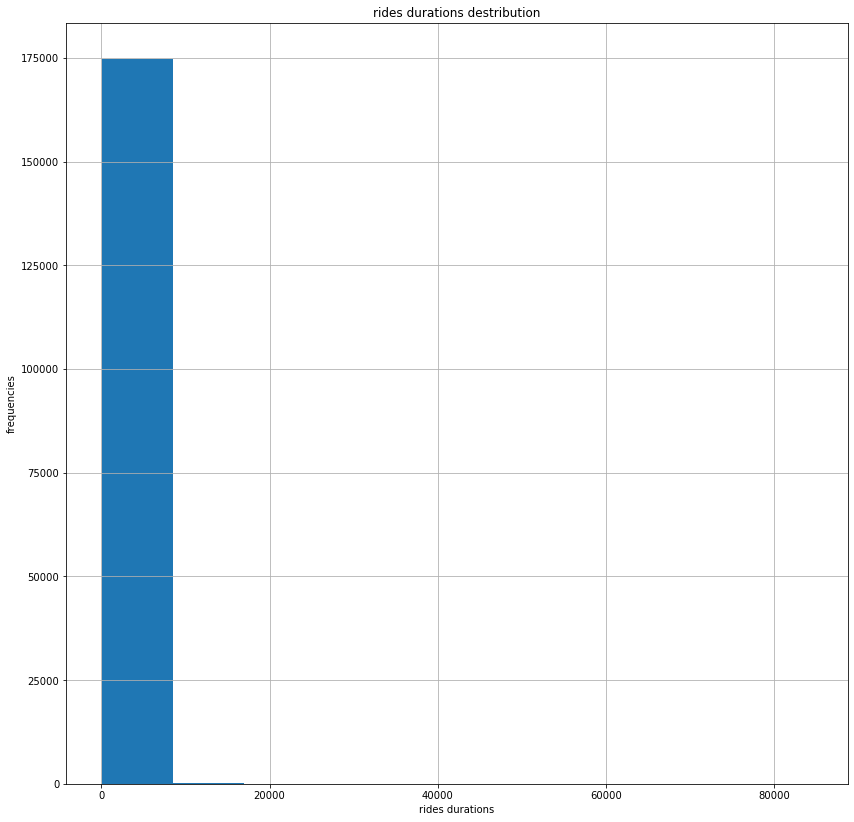

```python
df["duration_sec"].hist(figsize=(14,14))
plt.title('rides durations destribution')
plt.xlabel('rides durations')
plt.ylabel('frequencies')
plt.show()
```

> **comment:**

> the duration time in second is very skewed to the right.

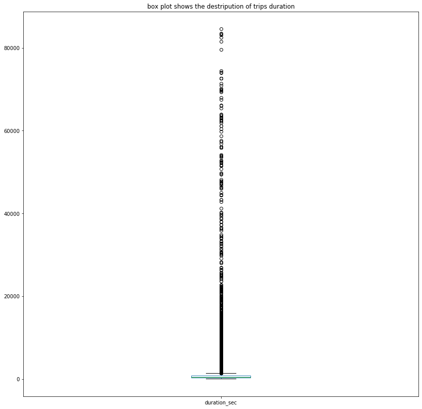

```python
cols = np.r_[0]
df.iloc[:, cols].plot(figsize=(14,14),kind='box')
plt.title('box plot shows the destripution of trips duration')
plt.show()
```

> **Comments:**

> that shows us that there is out laiers here in the duration time

> let us handeling the outlaiers in the **duration_sec** column. we have to check those outlaiers may be there something in common between them.

```python
df[df["duration_sec"]>10000]
```

|  | duration_sec | start_time | end_time | user_type | member_birth_year | member_gender | age | year_of_ride | month_of_ride |
| --- | --- | --- | --- | --- | --- | --- | --- | --- | --- |
| 0 | 52185 | 2019-02-28 17:32:10.145 | 2019-03-01 08:01:55.975 | Customer | 1984 | Male | 36 | 2019 | 2 |
| 2 | 61854 | 2019-02-28 12:13:13.218 | 2019-03-01 05:24:08.146 | Customer | 1972 | Male | 48 | 2019 | 2 |
| 3 | 36490 | 2019-02-28 17:54:26.010 | 2019-03-01 04:02:36.842 | Subscriber | 1989 | Other | 31 | 2019 | 2 |
| 199 | 15123 | 2019-02-28 18:23:19.035 | 2019-02-28 22:35:22.294 | Subscriber | 1980 | Male | 40 | 2019 | 2 |
| 297 | 13061 | 2019-02-28 18:28:18.728 | 2019-02-28 22:05:59.954 | Subscriber | 1987 | Male | 33 | 2019 | 2 |
| ... | ... | ... | ... | ... | ... | ... | ... | ... | ... |
| 178416 | 31203 | 2019-02-01 08:40:28.487 | 2019-02-01 17:20:31.553 | Subscriber | 1989 | Male | 31 | 2019 | 2 |
| 178649 | 14321 | 2019-02-01 12:50:10.691 | 2019-02-01 16:48:51.797 | Customer | 1977 | Other | 43 | 2019 | 2 |
| 178656 | 12894 | 2019-02-01 13:13:12.725 | 2019-02-01 16:48:07.003 | Subscriber | 1996 | Other | 24 | 2019 | 2 |
| 179732 | 10568 | 2019-02-01 10:08:37.189 | 2019-02-01 13:04:45.198 | Subscriber | 1989 | Male | 31 | 2019 | 2 |
| 182411 | 13609 | 2019-02-01 04:38:43.601 | 2019-02-01 08:25:33.493 | Subscriber | 1982 | Male | 38 | 2019 | 2 |

358 rows × 9 columns

> **Comment:**

> outlaiers numbers are small , we can drop them.

### 2-Age

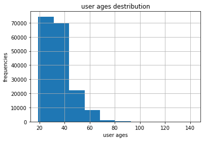

```python
df['age'].hist()
plt.title('user ages destribution')
plt.xlabel('user ages')
plt.ylabel('frequencies')
plt.show()
```

> **Comments:**

> -the distribution is right skewed.

> -it showes that people between 20 and 50 ages rides more often than the people who are between 60 and more than 80.

> -there is outlaiers in the ages, lets see more about that.

> later , i would like to see if as log as the age increase the frequency of the rides decrease or not. i suspect that is right.

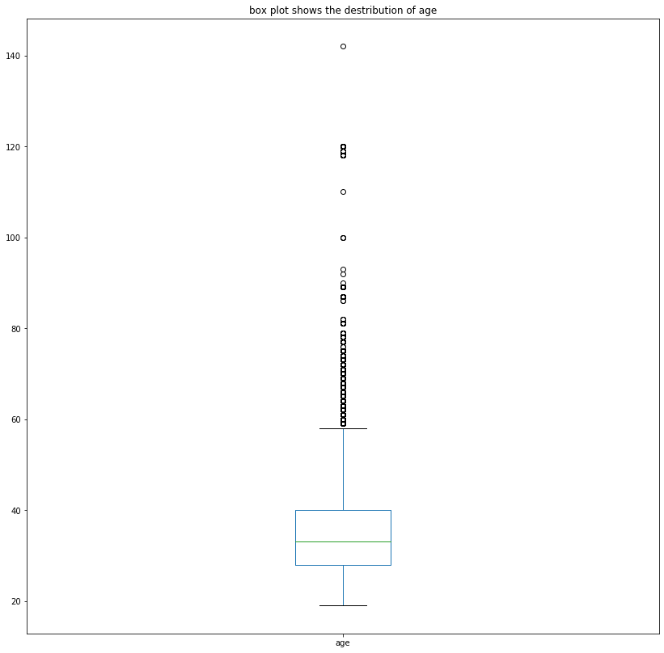

```python
cols = np.r_[-3]
df.iloc[:, cols].plot(figsize=(14,14),kind='box')
plt.title('box plot shows the destribution of age')
plt.show()
```

> **Comments:**

> let us handeling the outlaiers in the **age** column. we have to check those outlaiers may be there something in common between them.

```python
df[df["age"]>80]
```

|  | duration_sec | start_time | end_time | user_type | member_birth_year | member_gender | age | year_of_ride | month_of_ride |
| --- | --- | --- | --- | --- | --- | --- | --- | --- | --- |
| 1285 | 148 | 2019-02-28 19:29:17.627 | 2019-02-28 19:31:45.967 | Subscriber | 1900 | Male | 120 | 2019 | 2 |
| 5197 | 217 | 2019-02-28 13:51:46.238 | 2019-02-28 13:55:24.127 | Subscriber | 1931 | Male | 89 | 2019 | 2 |
| 5266 | 384 | 2019-02-28 13:35:05.428 | 2019-02-28 13:41:30.223 | Subscriber | 1931 | Male | 89 | 2019 | 2 |
| 5447 | 147 | 2019-02-28 13:08:56.935 | 2019-02-28 13:11:24.062 | Subscriber | 1931 | Male | 89 | 2019 | 2 |
| 10827 | 1315 | 2019-02-27 19:21:34.436 | 2019-02-27 19:43:30.008 | Subscriber | 1900 | Male | 120 | 2019 | 2 |
| ... | ... | ... | ... | ... | ... | ... | ... | ... | ... |
| 177885 | 517 | 2019-02-01 18:38:40.471 | 2019-02-01 18:47:18.392 | Subscriber | 1902 | Female | 118 | 2019 | 2 |
| 177955 | 377 | 2019-02-01 18:23:33.411 | 2019-02-01 18:29:50.795 | Subscriber | 1933 | Female | 87 | 2019 | 2 |
| 179280 | 355 | 2019-02-01 14:32:42.247 | 2019-02-01 14:38:37.896 | Subscriber | 1938 | Male | 82 | 2019 | 2 |
| 182830 | 428 | 2019-02-01 07:45:05.934 | 2019-02-01 07:52:14.922 | Subscriber | 1901 | Male | 119 | 2019 | 2 |
| 183388 | 490 | 2019-02-01 00:39:53.112 | 2019-02-01 00:48:03.338 | Subscriber | 1927 | Male | 93 | 2019 | 2 |

203 rows × 9 columns

> **Comment:**

### 3- Gender

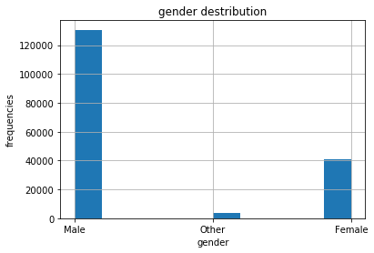

```python
df['member_gender'].hist()
plt.title('gender destribution')
plt.xlabel('gender')
plt.ylabel('frequencies')
plt.show()
```

> **Comments:**

> -the dataset is not balanced between male, female, and others.

> i would like to see if there is a relation ship between the gender and user subscription, to see is there is a gender kind more associated with a kind of subscribtion more than the other , or there is no relation.

### 4- User Type

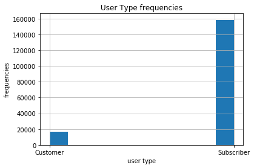

```python
df['user_type'].hist()
plt.title('User Type frequencies')
plt.xlabel('user type')
plt.ylabel('frequencies')
plt.show()
```

> **Comments:**

> -the dataset is not balanced.
> - it seems that the subscribers user type is more that the customer user type.

> i would like to look deeper in that later.

```python
df
```

|  | duration_sec | start_time | end_time | user_type | member_birth_year | member_gender | age | year_of_ride | month_of_ride |
| --- | --- | --- | --- | --- | --- | --- | --- | --- | --- |
| 0 | 52185 | 2019-02-28 17:32:10.145 | 2019-03-01 08:01:55.975 | Customer | 1984 | Male | 36 | 2019 | 2 |
| 2 | 61854 | 2019-02-28 12:13:13.218 | 2019-03-01 05:24:08.146 | Customer | 1972 | Male | 48 | 2019 | 2 |
| 3 | 36490 | 2019-02-28 17:54:26.010 | 2019-03-01 04:02:36.842 | Subscriber | 1989 | Other | 31 | 2019 | 2 |
| 4 | 1585 | 2019-02-28 23:54:18.549 | 2019-03-01 00:20:44.074 | Subscriber | 1974 | Male | 46 | 2019 | 2 |
| 5 | 1793 | 2019-02-28 23:49:58.632 | 2019-03-01 00:19:51.760 | Subscriber | 1959 | Male | 61 | 2019 | 2 |
| ... | ... | ... | ... | ... | ... | ... | ... | ... | ... |
| 183407 | 480 | 2019-02-01 00:04:49.724 | 2019-02-01 00:12:50.034 | Subscriber | 1996 | Male | 24 | 2019 | 2 |
| 183408 | 313 | 2019-02-01 00:05:34.744 | 2019-02-01 00:10:48.502 | Subscriber | 1984 | Male | 36 | 2019 | 2 |
| 183409 | 141 | 2019-02-01 00:06:05.549 | 2019-02-01 00:08:27.220 | Subscriber | 1990 | Male | 30 | 2019 | 2 |
| 183410 | 139 | 2019-02-01 00:05:34.360 | 2019-02-01 00:07:54.287 | Subscriber | 1988 | Male | 32 | 2019 | 2 |
| 183411 | 271 | 2019-02-01 00:00:20.636 | 2019-02-01 00:04:52.058 | Subscriber | 1989 | Male | 31 | 2019 | 2 |

175147 rows × 9 columns

### Cleansing after exploring the variables of interest

```python
indx_duration=df[df["duration_sec"]>10000].index
```

```python
'''-------------Dropping Rows that contains outlaiers in duration----------------'''
df.drop(indx_duration , inplace=True)
```

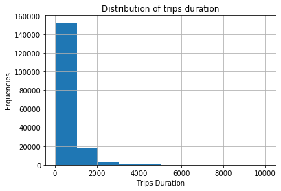

```python
df['duration_sec'].hist()
plt.title('Distribution of trips duration')
plt.xlabel('Trips Duration')
plt.ylabel('Frquencies')
plt.show()
```

```python
indx_ages=df[df["age"]>80].index
```

```python
'''-------------Dropping Rows that contains outlaiers in ages----------------'''
df.drop(indx_ages , inplace=True)
```

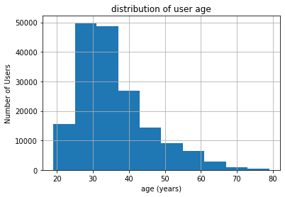

```python
df['age'].hist()
plt.title('distribution of user age')
plt.xlabel('age (years)')
plt.ylabel('Number of Users')
plt.show()
```

### now let's see how is our data after cleaning

```python
df.sample(5)
```

|  | duration_sec | start_time | end_time | user_type | member_birth_year | member_gender | age | year_of_ride | month_of_ride |
| --- | --- | --- | --- | --- | --- | --- | --- | --- | --- |
| 69676 | 1015 | 2019-02-19 18:59:07.967 | 2019-02-19 19:16:03.193 | Subscriber | 1952 | Male | 68 | 2019 | 2 |
| 6748 | 487 | 2019-02-28 09:45:02.172 | 2019-02-28 09:53:09.784 | Subscriber | 1988 | Male | 32 | 2019 | 2 |
| 64626 | 1457 | 2019-02-20 11:15:47.504 | 2019-02-20 11:40:05.250 | Subscriber | 1993 | Female | 27 | 2019 | 2 |
| 168764 | 358 | 2019-02-04 13:37:49.273 | 2019-02-04 13:43:47.412 | Subscriber | 1978 | Female | 42 | 2019 | 2 |
| 56238 | 531 | 2019-02-21 09:10:33.889 | 2019-02-21 09:19:25.752 | Subscriber | 1956 | Male | 64 | 2019 | 2 |

```python
df.describe()
```

|  | duration_sec | member_birth_year | age | year_of_ride | month_of_ride |
| --- | --- | --- | --- | --- | --- |
| count | 174586.000000 | 174586.000000 | 174586.000000 | 174586.0 | 174586.0 |
| mean | 647.883691 | 1984.881462 | 35.118538 | 2019.0 | 2.0 |
| std | 594.125934 | 9.870449 | 9.870449 | 0.0 | 0.0 |
| min | 61.000000 | 1941.000000 | 19.000000 | 2019.0 | 2.0 |
| 25% | 323.000000 | 1980.000000 | 28.000000 | 2019.0 | 2.0 |
| 50% | 510.000000 | 1987.000000 | 33.000000 | 2019.0 | 2.0 |
| 75% | 787.000000 | 1992.000000 | 40.000000 | 2019.0 | 2.0 |
| max | 9994.000000 | 2001.000000 | 79.000000 | 2019.0 | 2.0 |

```python
df.info()
```

```
<class 'pandas.core.frame.DataFrame'>
Int64Index: 174586 entries, 4 to 183411
Data columns (total 9 columns):
duration_sec         174586 non-null int64
start_time           174586 non-null datetime64[ns]
end_time             174586 non-null datetime64[ns]
user_type            174586 non-null object
member_birth_year    174586 non-null int64
member_gender        174586 non-null object
age                  174586 non-null int64
year_of_ride         174586 non-null int64
month_of_ride        174586 non-null int64
dtypes: datetime64[ns](2), int64(5), object(2)
memory usage: 13.3+ MB
```

```python
df.shape
```

```
(174586, 9)
```

### Discuss the distribution(s) of your variable(s) of interest. Were there any unusual points? Did you need to perform any transformations?

> yes, i found that the durations in seconds column have some outlaiers , there number is very small so we are just going to drop them.

> also there is out laiers in the age , they are small number of rows , so i just removed them.

### Of the features you investigated, were there any unusual distributions? Did you perform any operations on the data to tidy, adjust, or change the form of the data? If so, why did you do this?

> -yes there was

> -the duration is very skewed to the right and that is logic that not all people can take the rides for a long durations, so most of them are accumlating under 10000 seconds, after removing outlaiers the duration in secound values are skewed to the right but not like what it was.

> -a new column was added named age , calculated from the birth year of the users.

> -the dataset is not balanced with respect to the gender and user types, and those iam going to look deeper if these un balanced categories have a relation between them, later..

## Bivariate Exploration

> In this section, investigate relationships between pairs of variables in the data.

### 1- let's see the relation between the duration time and age of the user members

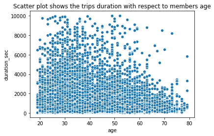

```python
sns.scatterplot(x='age', y = 'duration_sec', data = df, palette='gist_ncar_r')
plt.title('Scatter plot shows the trips duration with respect to members age')
plt.show()
```

> **Comments:**

> -the graph is not visually clear id the correlation between these two virable is directly or inversely proportional, we can check that with another method.

> -and that shows that the people who do much rides are aged between 20 and 50 ears old, and those how are younger makes large rides durations.

```python
df['age'].corr(df['duration_sec'])
```

```
0.025472933865079206
```

> **Comments:**

### 2- let's see the relation between the duration time and gender of the user members

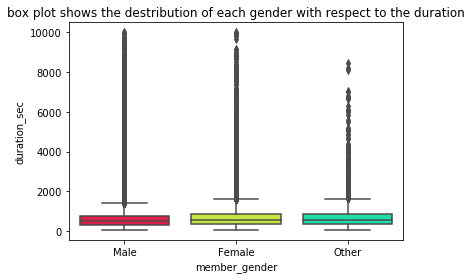

```python
fig=sns.boxplot(x='member_gender', y = 'duration_sec', data = df, palette='gist_ncar_r')
plt.title('box plot shows the destribution of each gender with respect to the duration')
plt.show()
```

> **Comment**

> we can conclude from here that the female are doing the higher rides duration than males and others

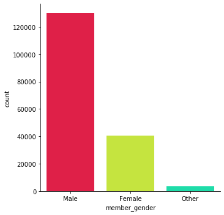

```python
sns.catplot(x='member_gender',kind="count", data = df, palette='gist_ncar_r')
```

> **Comments:**

> -although males do the more rides than females and others. but from the privous graph showed us that the females then the others are doing a higher rides duration than men.

### 3- let's see the relation between the duration time and user members type

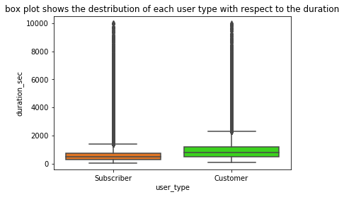

```python
fig=sns.boxplot(x='user_type', y = 'duration_sec', data = df, palette='gist_ncar_r')
plt.title('box plot shows the destribution of each user type with respect to the duration')
plt.show()
```

> **Comments**

> it is obvious here to see that the customers are doing long duration time thanthe subscribesrs in their trips.

### Talk about some of the relationships you observed in this part of the investigation. How did the feature(s) of interest vary with other features in the dataset?

> -i found that the trip duration is depentable on the age but not very much, i did not expect that , i expected that i will found it is very correlated.

### Did you observe any interesting relationships between the other features (not the main feature(s) of interest)?

> Actually yes! , the most observable thing is the number of the males how take the rides is very high , while the females are the ones who make the longest duration , we can guess that mommies are tends to go for a long trips because of reaching their children to the school, then go to their work.

## Multivariate Exploration

> i'd like to see the relation between the duration time and age how will act while mixing them with gender feature or user member type.

> i think we will get useful insights

> let's start with duration time and age with respect of user type

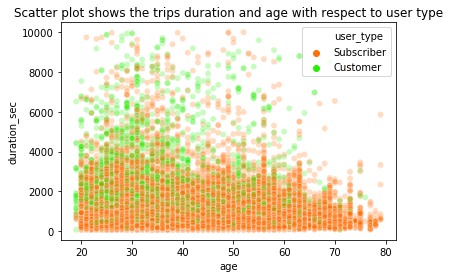

```python
sns.scatterplot(x='age', y = 'duration_sec', data = df, hue = 'user_type', palette='gist_ncar_r', alpha=0.25)
plt.title('Scatter plot shows the trips duration and age with respect to user type')
plt.show()
```

```python
df_sub = df[df["user_type"] == 'Subscriber']
df_cus = df[df["user_type"] == 'Customer']
```

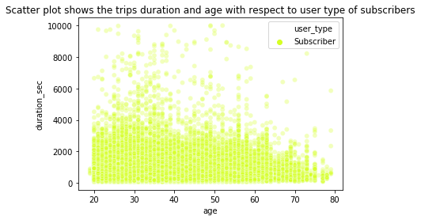

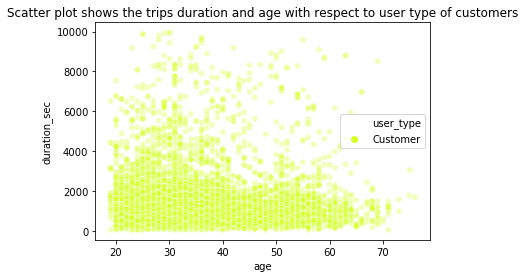

```python
sns.scatterplot(x='age', y = 'duration_sec', data = df_sub, hue = 'user_type', palette='gist_ncar_r', alpha=0.30)
plt.title('Scatter plot shows the trips duration and age with respect to user type of subscribers')
plt.show()
sns.scatterplot(x='age', y = 'duration_sec', data = df_cus, hue = 'user_type', palette='gist_ncar_r', alpha=0.30)
plt.title('Scatter plot shows the trips duration and age with respect to user type of customers')
plt.show()
```

> **Comments:**

> -these two graphs seems to have the same trends in both the customer and subcribes with respect of age and trips durations.

> -the age of the customers also have small ages than the subscribers ones.

> then , let's start with duration time and age with respect of gender.

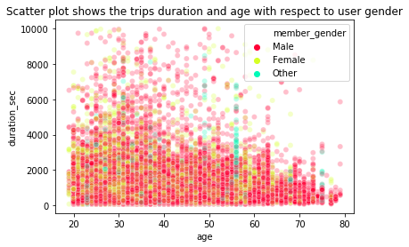

```python
sns.scatterplot(x='age', y = 'duration_sec', data = df, hue = 'member_gender', palette='gist_ncar_r', alpha=0.25)
plt.title('Scatter plot shows the trips duration and age with respect to user gender')
plt.show()
```

```python
df_male = df[df["member_gender"] == 'Male']
df_female = df[df["member_gender"] == 'Female']
df_other = df[df["member_gender"] == 'Other']
```

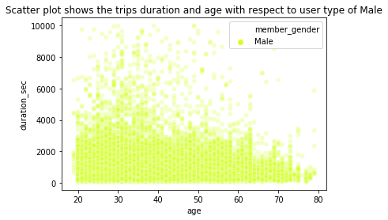

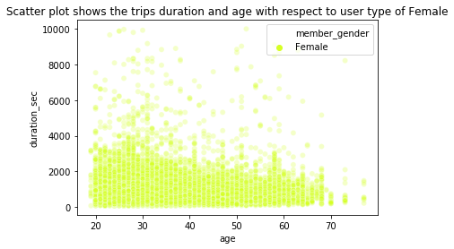

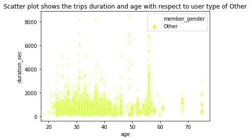

```python
sns.scatterplot(x='age', y = 'duration_sec', data = df_male, hue = 'member_gender', palette='gist_ncar_r', alpha=0.25)
plt.title('Scatter plot shows the trips duration and age with respect to user type of Male')
plt.show()
sns.scatterplot(x='age', y = 'duration_sec', data = df_female, hue = 'member_gender', palette='gist_ncar_r', alpha=0.25)
plt.title('Scatter plot shows the trips duration and age with respect to user type of Female')
plt.show()
sns.scatterplot(x='age', y = 'duration_sec', data = df_other, hue = 'member_gender', palette='gist_ncar_r', alpha=0.25)
plt.title('Scatter plot shows the trips duration and age with respect to user type of Other')
plt.show()
```

> **Comment**:

> it seems that the female and males share the same trends , except for the others , people who their age is about 55 or 56 make a higher duration,and the frequent is high as it appears from the density of dots.

### Talk about some of the relationships you observed in this part of the investigation. Were there features that strengthened each other in terms of looking at your feature(s) of interest?

> i expect to see a diffrent in trends between males and females for age and trip durationas as we conclude before that the femals make long durations than males. but unfortunately they share the same trends exept that the number of males is much higher than the females that appears from the density.

> -also that the age of the customers also have small ages than the subscribers ones. from that information we can make market segmentation for younger customers users , and older subscribers ones.

### Were there any interesting or surprising interactions between features?

> yes, people who their age is about 55 or 56 make a higher duration, and the frequent is high as it appears from the density of dots. we need more data to figure out why specially that age frequents and trip durations are high.